# Project: Investigate a Dataset - [TMDb movie data]

- Introduction
- Data Wrangling
- Exploratory Data Analysis
- Conclusions

## Introduction

### Dataset Description

> [ TMDb movie data] is adata collected about movies ,it has 21 columns which are(id,imdb_id, popularity, budget,revenue,original_title, cast, homepage, director, tagline, overview, runtime genres, production_companies,release_date, vote_count, vote_average,release_year,budget_ad,revenue_adj) here i will answer the questions: which genres are the most popular from year to year? what kinds of properties are associated with movies have high revenues?

```python
import pandas as pd
import numpy as np
import matplotlib.pyplot as plt
```

```python
# Upgrade pandas to use dataframe.explode() function.
!pip install --upgrade pandas==0.25.0
```

[output not shown]

[output not shown]

[output cut: 945 more lines]

[output not shown]

## Data Wrangling

==> Here i loaded my data about tmdb movies and began to get familiar with it.Then began to clean it deleted duplicated data and rows with nan values,after that i began to delete columns which i would not use through my analysis

```python
df=pd.read_csv('tmdb-movies.csv', index_col="id")
df.head()
```

| id | imdb_id | popularity | budget | revenue | original_title | cast | homepage | director | tagline | keywords | overview | runtime | genres | production_companies | release_date | vote_count | vote_average | release_year | budget_adj | revenue_adj |
| --- | --- | --- | --- | --- | --- | --- | --- | --- | --- | --- | --- | --- | --- | --- | --- | --- | --- | --- | --- | --- |
| 135397 | tt0369610 | 32.985763 | 150000000 | 1513528810 | Jurassic World | Chris Pratt\|Bryce Dallas Howard\|Irrfan Khan\|Vi... | http://www.jurassicworld.com/ | Colin Trevorrow | The park is open. | monster\|dna\|tyrannosaurus rex\|velociraptor\|island | Twenty-two years after the events of Jurassic ... | 124 | Action\|Adventure\|Science Fiction\|Thriller | Universal Studios\|Amblin Entertainment\|Legenda... | 6/9/15 | 5562 | 6.5 | 2015 | 1.379999e+08 | 1.392446e+09 |
| 76341 | tt1392190 | 28.419936 | 150000000 | 378436354 | Mad Max: Fury Road | Tom Hardy\|Charlize Theron\|Hugh Keays-Byrne\|Nic... | http://www.madmaxmovie.com/ | George Miller | What a Lovely Day. | future\|chase\|post-apocalyptic\|dystopia\|australia | An apocalyptic story set in the furthest reach... | 120 | Action\|Adventure\|Science Fiction\|Thriller | Village Roadshow Pictures\|Kennedy Miller Produ... | 5/13/15 | 6185 | 7.1 | 2015 | 1.379999e+08 | 3.481613e+08 |
| 262500 | tt2908446 | 13.112507 | 110000000 | 295238201 | Insurgent | Shailene Woodley\|Theo James\|Kate Winslet\|Ansel... | http://www.thedivergentseries.movie/#insurgent | Robert Schwentke | One Choice Can Destroy You | based on novel\|revolution\|dystopia\|sequel\|dyst... | Beatrice Prior must confront her inner demons ... | 119 | Adventure\|Science Fiction\|Thriller | Summit Entertainment\|Mandeville Films\|Red Wago... | 3/18/15 | 2480 | 6.3 | 2015 | 1.012000e+08 | 2.716190e+08 |
| 140607 | tt2488496 | 11.173104 | 200000000 | 2068178225 | Star Wars: The Force Awakens | Harrison Ford\|Mark Hamill\|Carrie Fisher\|Adam D... | http://www.starwars.com/films/star-wars-episod... | J.J. Abrams | Every generation has a story. | android\|spaceship\|jedi\|space opera\|3d | Thirty years after defeating the Galactic Empi... | 136 | Action\|Adventure\|Science Fiction\|Fantasy | Lucasfilm\|Truenorth Productions\|Bad Robot | 12/15/15 | 5292 | 7.5 | 2015 | 1.839999e+08 | 1.902723e+09 |
| 168259 | tt2820852 | 9.335014 | 190000000 | 1506249360 | Furious 7 | Vin Diesel\|Paul Walker\|Jason Statham\|Michelle ... | http://www.furious7.com/ | James Wan | Vengeance Hits Home | car race\|speed\|revenge\|suspense\|car | Deckard Shaw seeks revenge against Dominic Tor... | 137 | Action\|Crime\|Thriller | Universal Pictures\|Original Film\|Media Rights ... | 4/1/15 | 2947 | 7.3 | 2015 | 1.747999e+08 | 1.385749e+09 |

```python
df.tail(20)
```

| id | imdb_id | popularity | budget | revenue | original_title | cast | homepage | director | tagline | keywords | overview | runtime | genres | production_companies | release_date | vote_count | vote_average | release_year | budget_adj | revenue_adj |
| --- | --- | --- | --- | --- | --- | --- | --- | --- | --- | --- | --- | --- | --- | --- | --- | --- | --- | --- | --- | --- |
| 17102 | tt0059127 | 0.212716 | 0 | 0 | Dracula: Prince of Darkness | Christopher Lee\|Barbara Shelley\|Andrew Keir\|Fr... | NaN | Terence Fisher | DEAD for Ten Years DRACULA, Prince of Darkness... | castle\|vampire\|dracula\|sequel\|blood | Whilst vacationing in the Carpathian Mountain,... | 90 | Horror | Seven Arts Productions\|Hammer Film Productions | 1/9/66 | 16 | 5.7 | 1966 | 0.000000e+00 | 0.000000e+00 |
| 28763 | tt0060548 | 0.034555 | 0 | 0 | Island of Terror | Peter Cushing\|Edward Judd\|Carole Gray\|Eddie By... | NaN | Terence Fisher | How could they stop the devouring death...that... | monster\|island\|fog\|bone\|creature | A small island community is overrun with creep... | 89 | Science Fiction\|Horror | Planet Film Productions\|Protelco | 6/20/66 | 13 | 5.3 | 1966 | 0.000000e+00 | 0.000000e+00 |
| 2161 | tt0060397 | 0.207257 | 5115000 | 12000000 | Fantastic Voyage | Stephen Boyd\|Raquel Welch\|Edmond O'Brien\|Donal... | NaN | Richard Fleischer | A Fantastic and Spectacular Voyage... Through ... | submarine\|coma\|claustrophobia\|wound\|laser | The science of miniaturization has been unlock... | 100 | Adventure\|Science Fiction | Twentieth Century Fox Film Corporation | 8/24/66 | 42 | 6.7 | 1966 | 3.436265e+07 | 8.061618e+07 |
| 28270 | tt0060445 | 0.206537 | 0 | 0 | Gambit | Michael Caine\|Shirley MacLaine\|Herbert Lom\|Joh... | NaN | Ronald Neame | Shirley MacLaine raises Michael Caine! | master thief | Harry Dean (Michael Caine) has a perfect plan ... | 109 | Action\|Comedy\|Crime | Universal Pictures | 12/16/66 | 14 | 6.1 | 1966 | 0.000000e+00 | 0.000000e+00 |
| 26268 | tt0060490 | 0.202473 | 0 | 0 | Harper | Paul Newman\|Lauren Bacall\|Julie Harris\|Arthur ... | NaN | Jack Smight | Harper takes a case - and the payoff is murder. | private eye\|lew harper | Harper is a cynical private eye in the best tr... | 121 | Action\|Drama\|Thriller\|Crime\|Mystery | Warner Bros. | 2/23/66 | 14 | 6.0 | 1966 | 0.000000e+00 | 0.000000e+00 |
| 15347 | tt0060182 | 0.342791 | 0 | 0 | Born Free | Virginia McKenna\|Bill Travers\|Geoffrey Keen\|Pe... | NaN | James Hill | From The Pages Of The Beloved Best Seller... A... | parents kids relationship\|famous score\|lion\|ag... | Born Free (1966) is an Open Road Films Ltd./Co... | 95 | Adventure\|Drama\|Action\|Family\|Foreign | High Road | 6/22/66 | 15 | 6.6 | 1966 | 0.000000e+00 | 0.000000e+00 |
| 37301 | tt0060165 | 0.227220 | 0 | 0 | A Big Hand for the Little Lady | Henry Fonda\|Joanne Woodward\|Jason Robards\|Paul... | NaN | Fielder Cook | All the action you can take...all the adventur... | poker game | A naive traveler in Laredo gets involved in a ... | 95 | Western | Eden Productions Inc. | 5/31/66 | 11 | 6.0 | 1966 | 0.000000e+00 | 0.000000e+00 |
| 15598 | tt0060086 | 0.163592 | 0 | 0 | Alfie | Michael Caine\|Shelley Winters\|Millicent Martin... | NaN | Lewis Gilbert | Is any man an Alfie? Ask any girl! | womanizer\|playboy | The film tells the story of a young man who le... | 114 | Comedy\|Drama\|Romance | NaN | 3/29/66 | 26 | 6.2 | 1966 | 0.000000e+00 | 0.000000e+00 |
| 31602 | tt0060232 | 0.146402 | 0 | 0 | The Chase | Marlon Brando\|Jane Fonda\|Robert Redford\|E.G. M... | NaN | Arthur Penn | The chase is on! | sheriff\|house party\|man hunt\|junkyard\|jump fro... | Most everyone in town thinks that Sheriff Cald... | 135 | Thriller\|Drama\|Crime | Horizon Pictures\|Columbia Pictures Corporation | 2/17/66 | 17 | 6.0 | 1966 | 0.000000e+00 | 0.000000e+00 |
| 13343 | tt0059221 | 0.141026 | 700000 | 0 | The Ghost & Mr. Chicken | Don Knotts\|Joan Staley\|Liam Redmond\|Dick Sarge... | NaN | Alan Rafkin | G-G-GUARANTEED! YOU'LL BE SCARED UNTIL YOU LAU... | newspaper\|haunted house\|organ\|slapstick\|trial | Luther Heggs aspires to being a reporter for h... | 90 | Comedy\|Family\|Mystery\|Romance | Universal Pictures | 1/20/66 | 14 | 6.1 | 1966 | 4.702610e+06 | 0.000000e+00 |
| 20277 | tt0061135 | 0.140934 | 0 | 0 | The Ugly Dachshund | Dean Jones\|Suzanne Pleshette\|Charles Ruggles\|K... | NaN | Norman Tokar | A HAPPY HONEYMOON GOES TO THE DOGS!...When a G... | great dane\|dachshund | The Garrisons (Dean Jones and Suzanne Pleshett... | 93 | Comedy\|Drama\|Family | Walt Disney Pictures | 2/16/66 | 14 | 5.7 | 1966 | 0.000000e+00 | 0.000000e+00 |
| 5921 | tt0060748 | 0.131378 | 0 | 0 | Nevada Smith | Steve McQueen\|Karl Malden\|Brian Keith\|Arthur K... | NaN | Henry Hathaway | Some called him savage- and some called him sa... | repayment\|revenge\|native american\|wild west\|ha... | Nevada Smith is the young son of an Indian mot... | 128 | Action\|Western | Paramount Pictures\|Solar Productions\|Embassy P... | 6/10/66 | 10 | 5.9 | 1966 | 0.000000e+00 | 0.000000e+00 |
| 31918 | tt0060921 | 0.317824 | 0 | 0 | The Russians Are Coming, The Russians Are Coming | Carl Reiner\|Eva Marie Saint\|Alan Arkin\|Brian K... | NaN | Norman Jewison | IT'S A PLOT! ...to make the world die laughing!! | cold war\|russian\|new england | Without hostile intent, a Soviet sub runs agro... | 126 | Comedy\|War | The Mirisch Corporation | 5/25/66 | 11 | 5.5 | 1966 | 0.000000e+00 | 0.000000e+00 |
| 20620 | tt0060955 | 0.089072 | 0 | 0 | Seconds | Rock Hudson\|Salome Jens\|John Randolph\|Will Gee... | NaN | John Frankenheimer | NaN | plastic surgery\|suspense | A secret organisation offers wealthy people a ... | 100 | Mystery\|Science Fiction\|Thriller\|Drama | Gibraltar Productions\|Joel Productions\|John Fr... | 10/5/66 | 22 | 6.6 | 1966 | 0.000000e+00 | 0.000000e+00 |
| 5060 | tt0060214 | 0.087034 | 0 | 0 | Carry On Screaming! | Kenneth Williams\|Jim Dale\|Harry H. Corbett\|Joa... | NaN | Gerald Thomas | Carry On Screaming with the Hilarious CARRY ON... | monster\|carry on\|horror spoof | The sinister Dr Watt has an evil scheme going.... | 87 | Comedy | Peter Rogers Productions\|Anglo-Amalgamated Fil... | 5/20/66 | 13 | 7.0 | 1966 | 0.000000e+00 | 0.000000e+00 |
| 21 | tt0060371 | 0.080598 | 0 | 0 | The Endless Summer | Michael Hynson\|Robert August\|Lord 'Tally Ho' B... | NaN | Bruce Brown | NaN | surfer\|surfboard\|surfing | The Endless Summer, by Bruce Brown, is one of ... | 95 | Documentary | Bruce Brown Films | 6/15/66 | 11 | 7.4 | 1966 | 0.000000e+00 | 0.000000e+00 |
| 20379 | tt0060472 | 0.065543 | 0 | 0 | Grand Prix | James Garner\|Eva Marie Saint\|Yves Montand\|Tosh... | NaN | John Frankenheimer | Cinerama sweeps YOU into a drama of speed and ... | car race\|racing\|formula 1 | Grand Prix driver Pete Aron is fired by his te... | 176 | Action\|Adventure\|Drama | Cherokee Productions\|Joel Productions\|Douglas ... | 12/21/66 | 20 | 5.7 | 1966 | 0.000000e+00 | 0.000000e+00 |
| 39768 | tt0060161 | 0.065141 | 0 | 0 | Beregis Avtomobilya | Innokentiy Smoktunovskiy\|Oleg Efremov\|Georgi Z... | NaN | Eldar Ryazanov | NaN | car\|trolley\|stealing car | An insurance agent who moonlights as a carthie... | 94 | Mystery\|Comedy | Mosfilm | 1/1/66 | 11 | 6.5 | 1966 | 0.000000e+00 | 0.000000e+00 |
| 21449 | tt0061177 | 0.064317 | 0 | 0 | What's Up, Tiger Lily? | Tatsuya Mihashi\|Akiko Wakabayashi\|Mie Hama\|Joh... | NaN | Woody Allen | WOODY ALLEN STRIKES BACK! | spoof | In comic Woody Allen's film debut, he took the... | 80 | Action\|Comedy | Benedict Pictures Corp. | 11/2/66 | 22 | 5.4 | 1966 | 0.000000e+00 | 0.000000e+00 |
| 22293 | tt0060666 | 0.035919 | 19000 | 0 | Manos: The Hands of Fate | Harold P. Warren\|Tom Neyman\|John Reynolds\|Dian... | NaN | Harold P. Warren | It's Shocking! It's Beyond Your Imagination! | fire\|gun\|drive\|sacrifice\|flashlight | A family gets lost on the road and stumbles up... | 74 | Horror | Norm-Iris | 11/15/66 | 15 | 1.5 | 1966 | 1.276423e+05 | 0.000000e+00 |

```python
df.shape
```

```
(10866, 20)
```

==> to find out if the column type is suitable to the column data . here the type is suitable to the data kind in each column

```python
df.dtypes
```

```
imdb_id                  object
popularity              float64
budget                    int64
revenue                   int64
original_title           object
cast                     object
homepage                 object
director                 object
tagline                  object
keywords                 object
overview                 object
runtime                   int64
genres                   object
production_companies     object
release_date             object
vote_count                int64
vote_average            float64
release_year              int64
budget_adj              float64
revenue_adj             float64
dtype: object
```

```python
df.info()
```

```
<class 'pandas.core.frame.DataFrame'>
Int64Index: 10866 entries, 135397 to 22293
Data columns (total 20 columns):
 #   Column                Non-Null Count  Dtype
---  ------                --------------  -----
 0   imdb_id               10856 non-null  object
 1   popularity            10866 non-null  float64
 2   budget                10866 non-null  int64
 3   revenue               10866 non-null  int64
 4   original_title        10866 non-null  object
 5   cast                  10790 non-null  object
 6   homepage              2936 non-null   object
 7   director              10822 non-null  object
 8   tagline               8042 non-null   object
 9   keywords              9373 non-null   object
 10  overview              10862 non-null  object
 11  runtime               10866 non-null  int64
 12  genres                10843 non-null  object
 13  production_companies  9836 non-null   object
 14  release_date          10866 non-null  object
 15  vote_count            10866 non-null  int64
 16  vote_average          10866 non-null  float64
 17  release_year          10866 non-null  int64
 18  budget_adj            10866 non-null  float64
 19  revenue_adj           10866 non-null  float64
dtypes: float64(4), int64(5), object(11)
memory usage: 1.3+ MB
```

```python
df.nunique()
```

```
imdb_id                 10855
popularity              10814
budget                    557
revenue                  4702
original_title          10571
cast                    10719
homepage                 2896
director                 5067
tagline                  7997
keywords                 8804
overview                10847
runtime                   247
genres                   2039
production_companies     7445
release_date             5909
vote_count               1289
vote_average               72
release_year               56
budget_adj               2614
revenue_adj              4840
dtype: int64
```

```
    ==> ibegan to search for duplicates and delete them , then deleted
    the columns i did not need through my analysis
```

```python
df.duplicated().sum()
```

```
1
```

```python
df.drop_duplicates(inplace = True)
```

===> dropping the columns

```python
df.drop(['imdb_id', 'homepage','tagline', 'keywords','overview','budget_adj','revenue_adj'], axis=1 , inplace = True)
```

```python
df.info()
```

```
<class 'pandas.core.frame.DataFrame'>
Int64Index: 10865 entries, 135397 to 22293
Data columns (total 13 columns):
 #   Column                Non-Null Count  Dtype
---  ------                --------------  -----
 0   popularity            10865 non-null  float64
 1   budget                10865 non-null  int64
 2   revenue               10865 non-null  int64
 3   original_title        10865 non-null  object
 4   cast                  10789 non-null  object
 5   director              10821 non-null  object
 6   runtime               10865 non-null  int64
 7   genres                10842 non-null  object
 8   production_companies  9835 non-null   object
 9   release_date          10865 non-null  object
 10  vote_count            10865 non-null  int64
 11  vote_average          10865 non-null  float64
 12  release_year          10865 non-null  int64
dtypes: float64(2), int64(5), object(6)
memory usage: 933.7+ KB
```

```python
df.head()
```

| id | popularity | budget | revenue | original_title | cast | director | runtime | genres | production_companies | release_date | vote_count | vote_average | release_year |
| --- | --- | --- | --- | --- | --- | --- | --- | --- | --- | --- | --- | --- | --- |
| 135397 | 32.985763 | 150000000 | 1513528810 | Jurassic World | Chris Pratt\|Bryce Dallas Howard\|Irrfan Khan\|Vi... | Colin Trevorrow | 124 | Action\|Adventure\|Science Fiction\|Thriller | Universal Studios\|Amblin Entertainment\|Legenda... | 6/9/15 | 5562 | 6.5 | 2015 |
| 76341 | 28.419936 | 150000000 | 378436354 | Mad Max: Fury Road | Tom Hardy\|Charlize Theron\|Hugh Keays-Byrne\|Nic... | George Miller | 120 | Action\|Adventure\|Science Fiction\|Thriller | Village Roadshow Pictures\|Kennedy Miller Produ... | 5/13/15 | 6185 | 7.1 | 2015 |
| 262500 | 13.112507 | 110000000 | 295238201 | Insurgent | Shailene Woodley\|Theo James\|Kate Winslet\|Ansel... | Robert Schwentke | 119 | Adventure\|Science Fiction\|Thriller | Summit Entertainment\|Mandeville Films\|Red Wago... | 3/18/15 | 2480 | 6.3 | 2015 |
| 140607 | 11.173104 | 200000000 | 2068178225 | Star Wars: The Force Awakens | Harrison Ford\|Mark Hamill\|Carrie Fisher\|Adam D... | J.J. Abrams | 136 | Action\|Adventure\|Science Fiction\|Fantasy | Lucasfilm\|Truenorth Productions\|Bad Robot | 12/15/15 | 5292 | 7.5 | 2015 |
| 168259 | 9.335014 | 190000000 | 1506249360 | Furious 7 | Vin Diesel\|Paul Walker\|Jason Statham\|Michelle ... | James Wan | 137 | Action\|Crime\|Thriller | Universal Pictures\|Original Film\|Media Rights ... | 4/1/15 | 2947 | 7.3 | 2015 |

==>the turn for deleting nan cells

```python
df.isnull().sum()
```

```
popularity                 0
budget                     0
revenue                    0
original_title             0
cast                      76
director                  44
runtime                    0
genres                    23
production_companies    1030
release_date               0
vote_count                 0
vote_average               0
release_year               0
dtype: int64
```

```python
df.dropna(inplace= True)
```

```python
df.info()
```

```
<class 'pandas.core.frame.DataFrame'>
Int64Index: 9772 entries, 135397 to 22293
Data columns (total 13 columns):
 #   Column                Non-Null Count  Dtype
---  ------                --------------  -----
 0   popularity            9772 non-null   float64
 1   budget                9772 non-null   int64
 2   revenue               9772 non-null   int64
 3   original_title        9772 non-null   object
 4   cast                  9772 non-null   object
 5   director              9772 non-null   object
 6   runtime               9772 non-null   int64
 7   genres                9772 non-null   object
 8   production_companies  9772 non-null   object
 9   release_date          9772 non-null   object
 10  vote_count            9772 non-null   int64
 11  vote_average          9772 non-null   float64
 12  release_year          9772 non-null   int64
dtypes: float64(2), int64(5), object(6)
memory usage: 839.8+ KB
```

```python
df.head(1)
```

| id | popularity | budget | revenue | original_title | cast | director | runtime | genres | production_companies | release_date | vote_count | vote_average | release_year |
| --- | --- | --- | --- | --- | --- | --- | --- | --- | --- | --- | --- | --- | --- |
| 135397 | 32.985763 | 150000000 | 1513528810 | Jurassic World | Chris Pratt\|Bryce Dallas Howard\|Irrfan Khan\|Vi... | Colin Trevorrow | 124 | Action\|Adventure\|Science Fiction\|Thriller | Universal Studios\|Amblin Entertainment\|Legenda... | 6/9/15 | 5562 | 6.5 | 2015 |

## Exploratory Data Analysis

> Here i am going answer the question WHICH GENRES ARE MOST POPULAR FROM YEAR TO YEAR? i used the release year column and find out that there are 56 years in my dataset then i used the columns genres,popularity and release year to show the most popular genres from year to year

===> the release year that i have in my data

```python
df.release_year.value_counts()
```

```
2014    635
2013    567
2015    558
2012    498
2009    474
2011    456
2008    441
2010    420
2007    389
2006    350
2005    323
2003    254
2004    253
2002    241
1999    212
```

[output cut: 42 more lines]

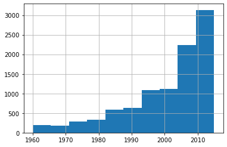

```python
df.release_year.hist();
```

==> here i noticed that most movies released in the period from 2000 to 2014

```python
df.groupby(["release_year", "genres"]).describe().popularity
```

| release_year | genres | count | mean | std | min | 25% | 50% | 75% | max |
| --- | --- | --- | --- | --- | --- | --- | --- | --- | --- |
| 1960 | Action\|Adventure\|Drama\|History\|Western | 1.0 | 0.310398 | NaN | 0.310398 | 0.310398 | 0.310398 | 0.310398 | 0.310398 |
|  | Action\|Adventure\|Western | 1.0 | 1.872132 | NaN | 1.872132 | 1.872132 | 1.872132 | 1.872132 | 1.872132 |
|  | Action\|Drama\|Foreign\|History\|War | 1.0 | 0.194948 | NaN | 0.194948 | 0.194948 | 0.194948 | 0.194948 | 0.194948 |
|  | Action\|Drama\|History | 1.0 | 1.136943 | NaN | 1.136943 | 1.136943 | 1.136943 | 1.136943 | 1.136943 |
|  | Action\|Drama\|History\|War | 1.0 | 0.256779 | NaN | 0.256779 | 0.256779 | 0.256779 | 0.256779 | 0.256779 |
| ... | ... | ... | ... | ... | ... | ... | ... | ... | ... |
| 2015 | War\|Action | 1.0 | 0.356519 | NaN | 0.356519 | 0.356519 | 0.356519 | 0.356519 | 0.356519 |
|  | War\|Adventure\|Science Fiction | 1.0 | 5.476958 | NaN | 5.476958 | 5.476958 | 5.476958 | 5.476958 | 5.476958 |
|  | War\|Drama | 1.0 | 0.561032 | NaN | 0.561032 | 0.561032 | 0.561032 | 0.561032 | 0.561032 |
|  | Western\|Drama | 1.0 | 0.747541 | NaN | 0.747541 | 0.747541 | 0.747541 | 0.747541 | 0.747541 |
|  | Western\|Drama\|Adventure\|Thriller | 1.0 | 9.110700 | NaN | 9.110700 | 9.110700 | 9.110700 | 9.110700 | 9.110700 |

5678 rows × 8 columns

# Research question 1

which genres are the most popular from year to year? i searched for the higest popularity for each year

==> pring the max popularity for each year

```python
max_pop= df.groupby(["release_year", "genres"]).max().popularity
max_pop
```

```
release_year  genres
1960          Action|Adventure|Drama|History|Western    0.310398
              Action|Adventure|Western                  1.872132
              Action|Drama|Foreign|History|War          0.194948
              Action|Drama|History                      1.136943
              Action|Drama|History|War                  0.256779
                                                          ...
2015          War|Action                                0.356519
              War|Adventure|Science Fiction             5.476958
              War|Drama                                 0.561032
              Western|Drama                             0.747541
              Western|Drama|Adventure|Thriller          9.110700
Name: popularity, Length: 5678, dtype: float64
```

```python
max_pop.head(1)
```

```
release_year  genres
1960          Action|Adventure|Drama|History|Western    0.310398
Name: popularity, dtype: float64
```

```python
pop_gen= df.groupby('release_year').max()[['genres','popularity']]
```

```python
pop_gen.head()
```

| release_year | genres | popularity |
| --- | --- | --- |
| 1960 | Thriller\|Music\|Comedy\|Crime | 2.610362 |
| 1961 | Western\|Action\|Adventure | 2.631987 |
| 1962 | Western\|Action\|Adventure\|Drama | 3.170651 |
| 1963 | Romance\|Comedy\|Drama | 2.508235 |
| 1964 | Western\|Action | 3.153791 |

```python
pop_gen
```

| release_year | genres | popularity |
| --- | --- | --- |
| 1960 | Thriller\|Music\|Comedy\|Crime | 2.610362 |
| 1961 | Western\|Action\|Adventure | 2.631987 |
| 1962 | Western\|Action\|Adventure\|Drama | 3.170651 |
| 1963 | Romance\|Comedy\|Drama | 2.508235 |
| 1964 | Western\|Action | 3.153791 |
| 1965 | War\|Drama\|Romance | 1.910465 |
| 1966 | Western | 1.227582 |
| 1967 | Western | 2.550704 |
| 1968 | Western | 3.309196 |
| 1969 | Thriller\|Fantasy\|Action\|Science Fiction\|Western | 1.778746 |
| 1970 | Western | 1.936962 |
| 1971 | Western | 3.072555 |
| 1972 | Western | 5.738034 |
| 1973 | Western | 2.272486 |
| 1974 | Thriller\|Horror\|Science Fiction | 3.264571 |
| 1975 | Western | 3.258151 |
| 1976 | Thriller\|Mystery\|Horror | 2.582657 |
| 1977 | Western | 12.037933 |
| 1978 | Thriller\|Mystery\|Drama | 1.697618 |
| 1979 | Western\|Comedy | 4.935897 |
| 1980 | Western\|History | 5.488441 |
| 1981 | Thriller\|Horror\|Mystery | 4.578300 |
| 1982 | Western\|Comedy\|Drama\|Music | 4.215642 |
| 1983 | War\|Drama | 4.828854 |
| 1984 | War\|Drama\|History | 4.831966 |
| 1985 | Thriller\|Horror | 6.095293 |
| 1986 | Thriller\|Horror | 2.485419 |
| 1987 | War\|Action\|Drama | 3.474728 |
| 1988 | War\|History | 3.777441 |
| 1989 | War\|Drama\|History\|Action\|Romance | 4.143585 |
| 1990 | Western\|Adventure | 2.679627 |
| 1991 | War\|Drama\|Romance | 3.852269 |
| 1992 | Western | 4.586426 |
| 1993 | Western\|Drama\|Comedy\|Romance | 2.571339 |
| 1994 | Western\|Action\|Comedy | 8.093754 |
| 1995 | War\|Adventure\|Drama\|Romance | 4.765359 |
| 1996 | Thriller\|Crime\|Mystery | 4.480733 |
| 1997 | Thriller\|Science Fiction\|Mystery\|Romance | 4.355219 |
| 1998 | Thriller\|Fantasy\|Crime\|Drama | 4.180540 |
| 1999 | Western\|Horror\|Thriller | 8.947905 |
| 2000 | Thriller\|Science Fiction\|Action | 4.271452 |
| 2001 | War\|Action\|Adventure\|Drama\|History | 8.575419 |
| 2002 | Western\|Animation\|Adventure\|Comedy\|Family | 8.095275 |
| 2003 | Western | 7.122455 |
| 2004 | Western\|History\|War | 5.827781 |
| 2005 | Thriller\|Science Fiction\|Adventure\|Action | 5.939927 |
| 2006 | Western\|Drama | 5.838503 |
| 2007 | Western | 4.965391 |
| 2008 | War\|Drama\|Foreign\|History | 8.466668 |
| 2009 | War\|Drama\|History\|Thriller | 9.432768 |
| 2010 | War\|Drama\|Action\|Adventure\|History | 9.363643 |
| 2011 | War\|Drama | 7.959228 |
| 2012 | War\|Action\|Thriller\|Science Fiction | 7.637767 |
| 2013 | Western\|Thriller | 6.112766 |
| 2014 | Western\|Drama | 24.949134 |
| 2015 | Western\|Drama\|Adventure\|Thriller | 32.985763 |

```
   ==> to make sure that all the years are exited
```

```python
pop_gen.shape
```

```
(56, 2)
```

==>> to visualized data i made apie char

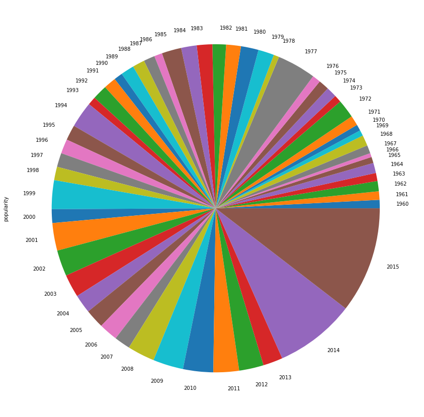

```python
pop_gen['popularity'].plot.pie(figsize=(15, 15));
```

=>>from that pie char we could see that there is a big difference in popularity in years (2014,2015)

===> here i want to analysis the genres column so i split the data inside it then begin to count values for each genre

```python
df_genre =df['genres'].str.split("|",expand=True)
```

```python
df_genre.head(1)
```

| id | 0 | 1 | 2 | 3 | 4 |
| --- | --- | --- | --- | --- | --- |
| 135397 | Action | Adventure | Science Fiction | Thriller | None |

```python
df_genre = df_genre.stack()
```

```python
df_genre = pd.DataFrame(df_genre)
```

```python
df_genre.head()
```

| id |  | 0 |
| --- | --- | --- |
| 135397 | 0 | Action |
|  | 1 | Adventure |
|  | 2 | Science Fiction |
|  | 3 | Thriller |
| 76341 | 0 | Action |

```python
df_genre.rename(columns={0:'genre'}, inplace=True)
df_genre.genre.value_counts()
```

```
Drama              4364
Comedy             3433
Thriller           2746
Action             2235
Romance            1570
Horror             1526
Adventure          1384
Crime              1299
Science Fiction    1136
Family             1095
Fantasy             840
Mystery             773
Animation           617
Music               339
Documentary         317
History             306
War                 258
Western             160
TV Movie            132
Foreign             120
Name: genre, dtype: int64
```

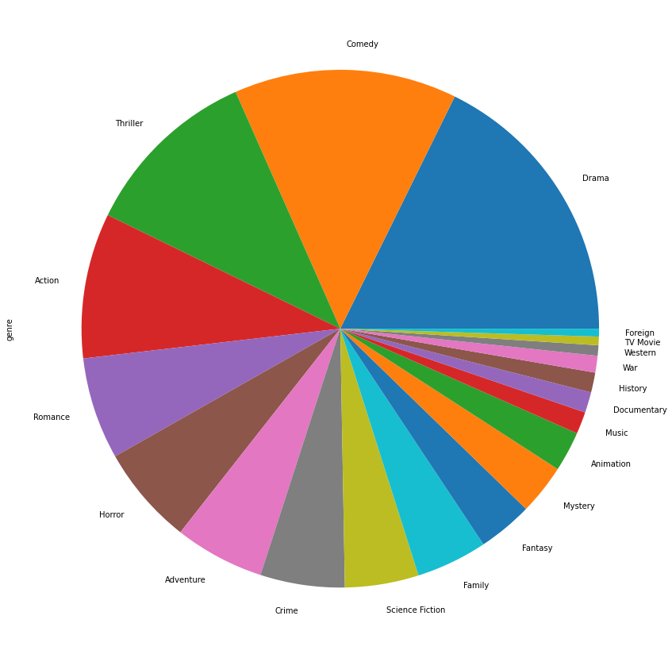

```python
df_genre.genre.value_counts().plot.pie(figsize=(15, 15));
```

===> the previous statistic shows that (drama, comedy,Thriller) are the most frequent genres, from the pie char we could figre out that (drama, comedy,Thriller, action and romance) genre took more than the half of our data.

# Research Question 2

what kinds of properties are associated with movies have high revenues?

=>to know more about my data i brought the highest revenue then i began to display the highest revenue from 75% to the max .There were so much movies so i decided to set two samples high revenue i set a point (10e+8) for it and low revenue from 75% to the point which i set

```python
df.revenue.max()
```

```
2781505847
```

```python
high_rev=df.query('revenue==2781505847')
high_rev
```

| id | popularity | budget | revenue | original_title | cast | director | runtime | genres | production_companies | release_date | vote_count | vote_average | release_year |
| --- | --- | --- | --- | --- | --- | --- | --- | --- | --- | --- | --- | --- | --- |
| 19995 | 9.432768 | 237000000 | 2781505847 | Avatar | Sam Worthington\|Zoe Saldana\|Sigourney Weaver\|S... | James Cameron | 162 | Action\|Adventure\|Fantasy\|Science Fiction | Ingenious Film Partners\|Twentieth Century Fox ... | 12/10/09 | 8458 | 7.1 | 2009 |

```python
df.revenue.describe()
```

```
count    9.772000e+03
mean     4.423121e+07
std      1.225889e+08
min      0.000000e+00
25%      0.000000e+00
50%      0.000000e+00
75%      3.104729e+07
max      2.781506e+09
Name: revenue, dtype: float64
```

```python
df_highest_revs=df.query('revenue >= 1000000000')
df_highest_revs
```

| id | popularity | budget | revenue | original_title | cast | director | runtime | genres | production_companies | release_date | vote_count | vote_average | release_year |
| --- | --- | --- | --- | --- | --- | --- | --- | --- | --- | --- | --- | --- | --- |
| 135397 | 32.985763 | 150000000 | 1513528810 | Jurassic World | Chris Pratt\|Bryce Dallas Howard\|Irrfan Khan\|Vi... | Colin Trevorrow | 124 | Action\|Adventure\|Science Fiction\|Thriller | Universal Studios\|Amblin Entertainment\|Legenda... | 6/9/15 | 5562 | 6.5 | 2015 |
| 140607 | 11.173104 | 200000000 | 2068178225 | Star Wars: The Force Awakens | Harrison Ford\|Mark Hamill\|Carrie Fisher\|Adam D... | J.J. Abrams | 136 | Action\|Adventure\|Science Fiction\|Fantasy | Lucasfilm\|Truenorth Productions\|Bad Robot | 12/15/15 | 5292 | 7.5 | 2015 |
| 168259 | 9.335014 | 190000000 | 1506249360 | Furious 7 | Vin Diesel\|Paul Walker\|Jason Statham\|Michelle ... | James Wan | 137 | Action\|Crime\|Thriller | Universal Pictures\|Original Film\|Media Rights ... | 4/1/15 | 2947 | 7.3 | 2015 |
| 211672 | 7.404165 | 74000000 | 1156730962 | Minions | Sandra Bullock\|Jon Hamm\|Michael Keaton\|Allison... | Kyle Balda\|Pierre Coffin | 91 | Family\|Animation\|Adventure\|Comedy | Universal Pictures\|Illumination Entertainment | 6/17/15 | 2893 | 6.5 | 2015 |
| 99861 | 5.944927 | 280000000 | 1405035767 | Avengers: Age of Ultron | Robert Downey Jr.\|Chris Hemsworth\|Mark Ruffalo... | Joss Whedon | 141 | Action\|Adventure\|Science Fiction | Marvel Studios\|Prime Focus\|Revolution Sun Studios | 4/22/15 | 4304 | 7.4 | 2015 |
| 19995 | 9.432768 | 237000000 | 2781505847 | Avatar | Sam Worthington\|Zoe Saldana\|Sigourney Weaver\|S... | James Cameron | 162 | Action\|Adventure\|Fantasy\|Science Fiction | Ingenious Film Partners\|Twentieth Century Fox ... | 12/10/09 | 8458 | 7.1 | 2009 |
| 12155 | 5.572950 | 200000000 | 1025467110 | Alice in Wonderland | Mia Wasikowska\|Johnny Depp\|Anne Hathaway\|Helen... | Tim Burton | 108 | Family\|Fantasy\|Adventure | Walt Disney Pictures\|Team Todd\|Tim Burton Prod... | 3/3/10 | 2853 | 6.3 | 2010 |
| 10193 | 2.711136 | 200000000 | 1063171911 | Toy Story 3 | Tom Hanks\|Tim Allen\|Ned Beatty\|Joan Cusack\|Mic... | Lee Unkrich | 103 | Animation\|Family\|Comedy | Walt Disney Pictures\|Pixar Animation Studios | 6/16/10 | 2924 | 7.5 | 2010 |
| 155 | 8.466668 | 185000000 | 1001921825 | The Dark Knight | Christian Bale\|Michael Caine\|Heath Ledger\|Aaro... | Christopher Nolan | 152 | Drama\|Action\|Crime\|Thriller | DC Comics\|Legendary Pictures\|Warner Bros.\|Syncopy | 7/16/08 | 8432 | 8.1 | 2008 |
| 12445 | 5.711315 | 125000000 | 1327817822 | Harry Potter and the Deathly Hallows: Part 2 | Daniel Radcliffe\|Rupert Grint\|Emma Watson\|Alan... | David Yates | 130 | Adventure\|Family\|Fantasy | Warner Bros.\|Heyday Films\|Moving Picture Compa... | 7/7/11 | 3750 | 7.7 | 2011 |
| 1865 | 4.955130 | 380000000 | 1021683000 | Pirates of the Caribbean: On Stranger Tides | Johnny Depp\|PenÃ©lope Cruz\|Geoffrey Rush\|Ian M... | Rob Marshall | 136 | Adventure\|Action\|Fantasy | Walt Disney Pictures\|Jerry Bruckheimer Films\|M... | 5/11/11 | 3180 | 6.3 | 2011 |
| 38356 | 0.760503 | 195000000 | 1123746996 | Transformers: Dark of the Moon | Shia LaBeouf\|John Malkovich\|Ken Jeong\|Frances ... | Michael Bay | 154 | Action\|Science Fiction\|Adventure | Paramount Pictures\|Di Bonaventura Pictures\|Has... | 6/28/11 | 2456 | 6.1 | 2011 |
| 24428 | 7.637767 | 220000000 | 1519557910 | The Avengers | Robert Downey Jr.\|Chris Evans\|Mark Ruffalo\|Chr... | Joss Whedon | 143 | Science Fiction\|Action\|Adventure | Marvel Studios | 4/25/12 | 8903 | 7.3 | 2012 |
| 49026 | 6.591277 | 250000000 | 1081041287 | The Dark Knight Rises | Christian Bale\|Michael Caine\|Gary Oldman\|Anne ... | Christopher Nolan | 165 | Action\|Crime\|Drama\|Thriller | Legendary Pictures\|Warner Bros.\|DC Entertainme... | 7/16/12 | 6723 | 7.5 | 2012 |
| 37724 | 5.603587 | 200000000 | 1108561013 | Skyfall | Daniel Craig\|Judi Dench\|Javier Bardem\|Ralph Fi... | Sam Mendes | 143 | Action\|Adventure\|Thriller | Columbia Pictures | 10/25/12 | 6137 | 6.8 | 2012 |
| 49051 | 4.218933 | 250000000 | 1017003568 | The Hobbit: An Unexpected Journey | Ian McKellen\|Martin Freeman\|Richard Armitage\|A... | Peter Jackson | 169 | Adventure\|Fantasy\|Action | WingNut Films\|New Line Cinema\|Metro-Goldwyn-Ma... | 11/26/12 | 6417 | 6.9 | 2012 |
| 122 | 7.122455 | 94000000 | 1118888979 | The Lord of the Rings: The Return of the King | Elijah Wood\|Ian McKellen\|Viggo Mortensen\|Liv T... | Peter Jackson | 201 | Adventure\|Fantasy\|Action | WingNut Films\|New Line Cinema | 12/1/03 | 5636 | 7.9 | 2003 |
| 597 | 4.355219 | 200000000 | 1845034188 | Titanic | Kate Winslet\|Leonardo DiCaprio\|Frances Fisher\|... | James Cameron | 194 | Drama\|Romance\|Thriller | Paramount Pictures\|Twentieth Century Fox Film ... | 11/18/97 | 4654 | 7.3 | 1997 |
| 109445 | 6.112766 | 150000000 | 1274219009 | Frozen | Kristen Bell\|Idina Menzel\|Jonathan Groff\|Josh ... | Chris Buck\|Jennifer Lee | 102 | Animation\|Adventure\|Family | Walt Disney Pictures\|Walt Disney Animation Stu... | 11/27/13 | 3369 | 7.5 | 2013 |
| 68721 | 4.946136 | 200000000 | 1215439994 | Iron Man 3 | Robert Downey Jr.\|Gwyneth Paltrow\|Guy Pearce\|D... | Shane Black | 130 | Action\|Adventure\|Science Fiction | Marvel Studios | 4/18/13 | 6882 | 6.9 | 2013 |
| 58 | 4.205992 | 200000000 | 1065659812 | Pirates of the Caribbean: Dead Man's Chest | Johnny Depp\|Orlando Bloom\|Keira Knightley\|Bill... | Gore Verbinski | 151 | Adventure\|Fantasy\|Action | Walt Disney Pictures\|Jerry Bruckheimer Films\|S... | 6/20/06 | 3181 | 6.8 | 2006 |
| 1642 | 1.136610 | 22000000 | 1106279658 | The Net | Sandra Bullock\|Jeremy Northam\|Dennis Miller\|We... | Irwin Winkler | 114 | Crime\|Drama\|Mystery\|Thriller\|Action | Columbia Pictures | 7/28/95 | 201 | 5.6 | 1995 |

```python
df_highest_revs.shape
```

```
(22, 13)
```

```python
df_highest_revs.nunique()
```

```
popularity              22
budget                  14
revenue                 22
original_title          22
cast                    22
director                18
runtime                 19
genres                  19
production_companies    20
release_date            22
vote_count              22
vote_average            13
release_year            11
dtype: int64
```

```python
df_highest_revs.describe()
```

|  | popularity | budget | revenue | runtime | vote_count | vote_average | release_year |
| --- | --- | --- | --- | --- | --- | --- | --- |
| count | 22.000000 | 2.200000e+01 | 2.200000e+01 | 22.000000 | 22.000000 | 22.000000 | 22.00000 |
| mean | 7.108372 | 1.910000e+08 | 1.333942e+09 | 140.272727 | 4779.727273 | 7.036364 | 2010.00000 |
| std | 6.312792 | 7.353587e+07 | 4.282809e+08 | 28.010511 | 2257.719080 | 0.627577 | 5.45981 |
| min | 0.760503 | 2.200000e+07 | 1.001922e+09 | 91.000000 | 201.000000 | 5.600000 | 1995.00000 |
| 25% | 4.502948 | 1.587500e+08 | 1.069505e+09 | 125.500000 | 3005.250000 | 6.575000 | 2009.25000 |
| 50% | 5.828121 | 2.000000e+08 | 1.140239e+09 | 139.000000 | 4479.000000 | 7.200000 | 2011.50000 |
| 75% | 7.579366 | 2.150000e+08 | 1.480946e+09 | 153.500000 | 6347.000000 | 7.500000 | 2013.00000 |
| max | 32.985763 | 3.800000e+08 | 2.781506e+09 | 201.000000 | 8903.000000 | 8.100000 | 2015.00000 |

```python
df_highest_revs.groupby(['revenue','original_title']).median()
```

| revenue | original_title | popularity | budget | runtime | vote_count | vote_average | release_year |
| --- | --- | --- | --- | --- | --- | --- | --- |
| 1001921825 | The Dark Knight | 8.466668 | 185000000 | 152 | 8432 | 8.1 | 2008 |
| 1017003568 | The Hobbit: An Unexpected Journey | 4.218933 | 250000000 | 169 | 6417 | 6.9 | 2012 |
| 1021683000 | Pirates of the Caribbean: On Stranger Tides | 4.955130 | 380000000 | 136 | 3180 | 6.3 | 2011 |
| 1025467110 | Alice in Wonderland | 5.572950 | 200000000 | 108 | 2853 | 6.3 | 2010 |
| 1063171911 | Toy Story 3 | 2.711136 | 200000000 | 103 | 2924 | 7.5 | 2010 |
| 1065659812 | Pirates of the Caribbean: Dead Man's Chest | 4.205992 | 200000000 | 151 | 3181 | 6.8 | 2006 |
| 1081041287 | The Dark Knight Rises | 6.591277 | 250000000 | 165 | 6723 | 7.5 | 2012 |
| 1106279658 | The Net | 1.136610 | 22000000 | 114 | 201 | 5.6 | 1995 |
| 1108561013 | Skyfall | 5.603587 | 200000000 | 143 | 6137 | 6.8 | 2012 |
| 1118888979 | The Lord of the Rings: The Return of the King | 7.122455 | 94000000 | 201 | 5636 | 7.9 | 2003 |
| 1123746996 | Transformers: Dark of the Moon | 0.760503 | 195000000 | 154 | 2456 | 6.1 | 2011 |
| 1156730962 | Minions | 7.404165 | 74000000 | 91 | 2893 | 6.5 | 2015 |
| 1215439994 | Iron Man 3 | 4.946136 | 200000000 | 130 | 6882 | 6.9 | 2013 |
| 1274219009 | Frozen | 6.112766 | 150000000 | 102 | 3369 | 7.5 | 2013 |
| 1327817822 | Harry Potter and the Deathly Hallows: Part 2 | 5.711315 | 125000000 | 130 | 3750 | 7.7 | 2011 |
| 1405035767 | Avengers: Age of Ultron | 5.944927 | 280000000 | 141 | 4304 | 7.4 | 2015 |
| 1506249360 | Furious 7 | 9.335014 | 190000000 | 137 | 2947 | 7.3 | 2015 |
| 1513528810 | Jurassic World | 32.985763 | 150000000 | 124 | 5562 | 6.5 | 2015 |
| 1519557910 | The Avengers | 7.637767 | 220000000 | 143 | 8903 | 7.3 | 2012 |
| 1845034188 | Titanic | 4.355219 | 200000000 | 194 | 4654 | 7.3 | 1997 |
| 2068178225 | Star Wars: The Force Awakens | 11.173104 | 200000000 | 136 | 5292 | 7.5 | 2015 |
| 2781505847 | Avatar | 9.432768 | 237000000 | 162 | 8458 | 7.1 | 2009 |

==>to see my data more clearly. those histograms we could notice the properties of most of the movies

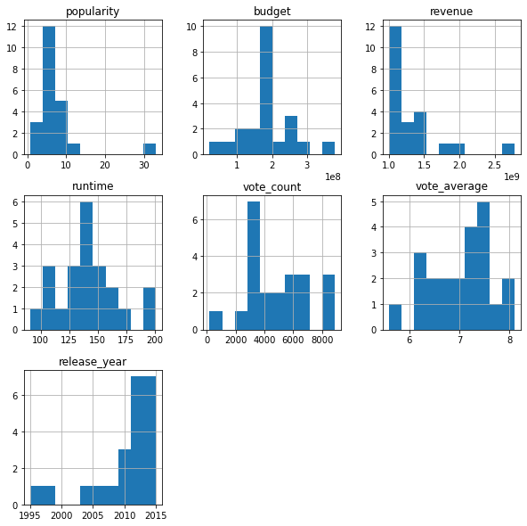

```python
df_highest_revs.hist(figsize=(10,10));
```

===> in the matrix below the relation between different properties is clarified

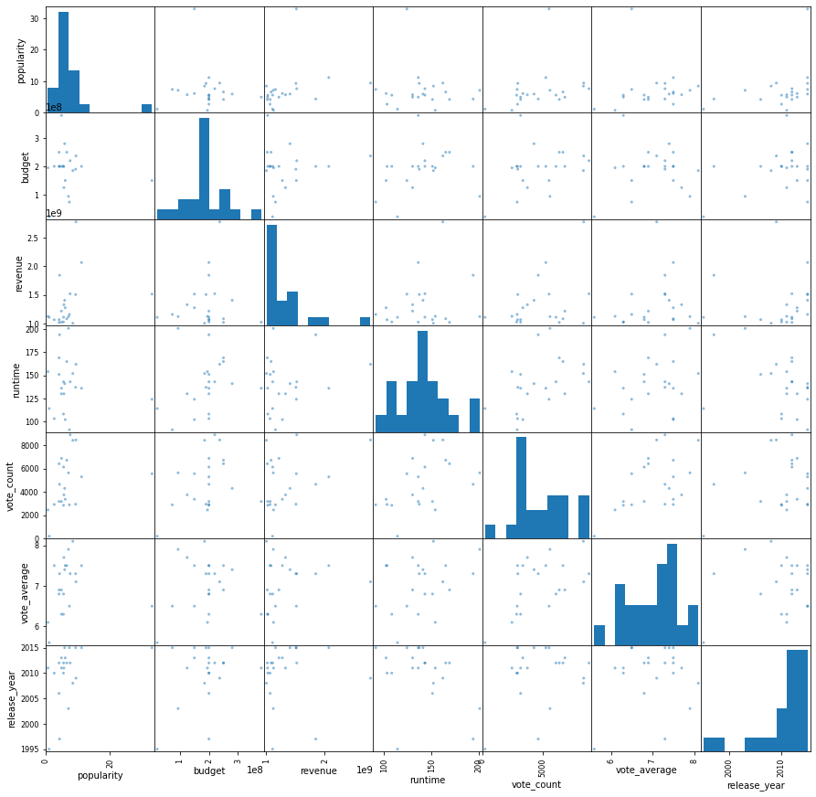

```python
pd.plotting.scatter_matrix(df_highest_revs, figsize=(15,15));
```

```python
df_low_revs= df.query('1000000000> revenue >31047290')
df_low_revs
```

| id | popularity | budget | revenue | original_title | cast | director | runtime | genres | production_companies | release_date | vote_count | vote_average | release_year |
| --- | --- | --- | --- | --- | --- | --- | --- | --- | --- | --- | --- | --- | --- |
| 76341 | 28.419936 | 150000000 | 378436354 | Mad Max: Fury Road | Tom Hardy\|Charlize Theron\|Hugh Keays-Byrne\|Nic... | George Miller | 120 | Action\|Adventure\|Science Fiction\|Thriller | Village Roadshow Pictures\|Kennedy Miller Produ... | 5/13/15 | 6185 | 7.1 | 2015 |
| 262500 | 13.112507 | 110000000 | 295238201 | Insurgent | Shailene Woodley\|Theo James\|Kate Winslet\|Ansel... | Robert Schwentke | 119 | Adventure\|Science Fiction\|Thriller | Summit Entertainment\|Mandeville Films\|Red Wago... | 3/18/15 | 2480 | 6.3 | 2015 |
| 281957 | 9.110700 | 135000000 | 532950503 | The Revenant | Leonardo DiCaprio\|Tom Hardy\|Will Poulter\|Domhn... | Alejandro González Iñárritu | 156 | Western\|Drama\|Adventure\|Thriller | Regency Enterprises\|Appian Way\|CatchPlay\|Anony... | 12/25/15 | 3929 | 7.2 | 2015 |
| 87101 | 8.654359 | 155000000 | 440603537 | Terminator Genisys | Arnold Schwarzenegger\|Jason Clarke\|Emilia Clar... | Alan Taylor | 125 | Science Fiction\|Action\|Thriller\|Adventure | Paramount Pictures\|Skydance Productions | 6/23/15 | 2598 | 5.8 | 2015 |
| 286217 | 7.667400 | 108000000 | 595380321 | The Martian | Matt Damon\|Jessica Chastain\|Kristen Wiig\|Jeff ... | Ridley Scott | 141 | Drama\|Adventure\|Science Fiction | Twentieth Century Fox Film Corporation\|Scott F... | 9/30/15 | 4572 | 7.6 | 2015 |
| ... | ... | ... | ... | ... | ... | ... | ... | ... | ... | ... | ... | ... | ... |
| 11778 | 0.959754 | 15000000 | 50000000 | The Deer Hunter | Robert De Niro\|John Cazale\|John Savage\|Christo... | Michael Cimino | 183 | Drama\|War | Universal Pictures\|EMI Films Ltd. | 12/8/78 | 464 | 7.4 | 1978 |
| 11455 | 0.608679 | 0 | 41590893 | Up in Smoke | Cheech Marin\|Tommy Chong\|Strother Martin\|Edie ... | Lou Adler | 86 | Comedy | Paramount Pictures | 1/1/78 | 103 | 6.5 | 1978 |
| 11327 | 0.512719 | 2300000 | 35000000 | Midnight Express | Brad Davis\|Irene Miracle\|Bo Hopkins\|Randy Quai... | Alan Parker | 121 | Drama\|Crime | Columbia Pictures\|Casablanca Filmworks | 10/6/78 | 141 | 7.5 | 1978 |
| 16214 | 0.044675 | 0 | 78000000 | Hooper | Burt Reynolds\|Robert Klein\|Adam West\|Jan-Micha... | Hal Needham | 107 | Action\|Comedy | Warner Bros. | 7/28/78 | 13 | 6.0 | 1978 |
| 396 | 0.670274 | 7500000 | 33736689 | Who's Afraid of Virginia Woolf? | Elizabeth Taylor\|Richard Burton\|George Segal\|S... | Mike Nichols | 131 | Drama | Chenault Productions | 6/21/66 | 74 | 7.5 | 1966 |

2421 rows × 13 columns

```python
df_rev_z= df_low_revs.query('revenue == 0')
df_rev_z.shape
```

```
(0, 13)
```

===> in the previous code i searched if the 'revenue' column has a (0) value in the data i choose there are no revenue = (0)

```python
df_low_revs.nunique()
```

```
popularity              2420
budget                   245
revenue                 2396
original_title          2392
cast                    2401
director                1022
runtime                  120
genres                   784
production_companies    1864
release_date            2008
vote_count              1205
vote_average              48
release_year              56
dtype: int64
```

```python
df_low_revs.duplicated('original_title').sum()
```

```
29
```

==> from those histograms we could notice the properties of most of the movies in that sample

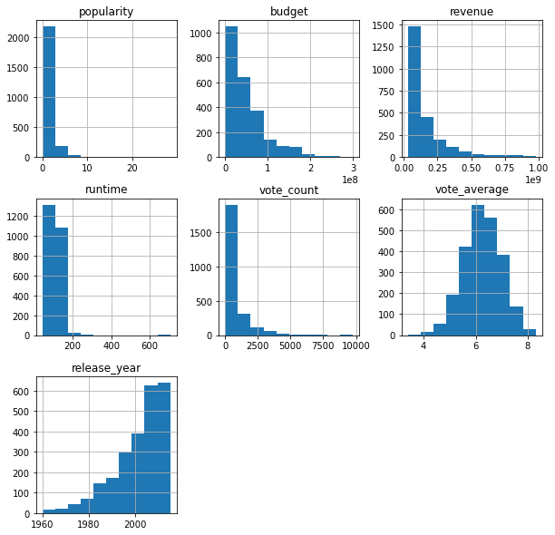

```python
df_low_revs.hist(figsize=(10,10));
```

===> that scatter matrix give a great view

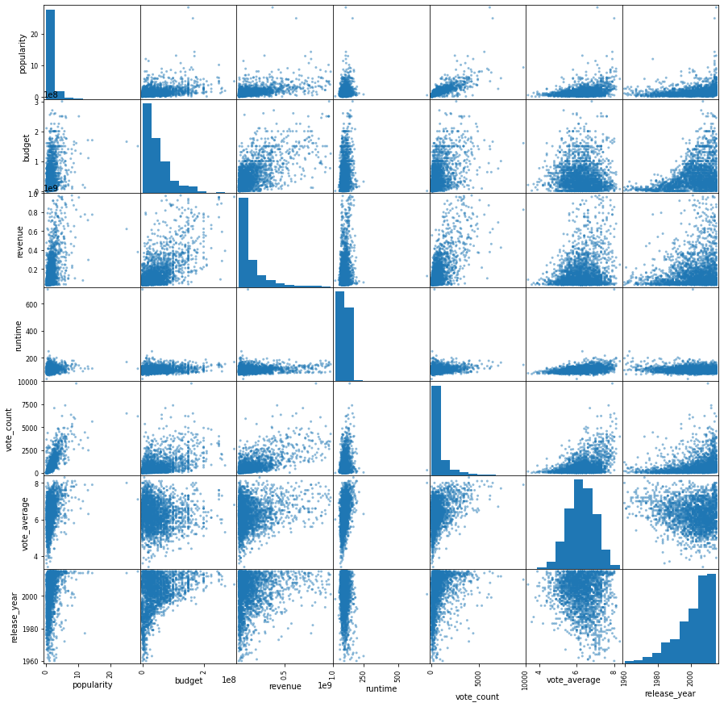

```python
pd.plotting.scatter_matrix(df_low_revs, figsize=(15,15));
```

===>> calculating the mean for high and low samples

```python
def mean():
    column_name=['revenue','budget','popularity','vote_count','vote_average','release_year']
    for c in column_name:
        df_highest_revs[c].mean(),df_low_revs[c].mean()
        mean = df_highest_revs[c].mean(),df_low_revs[c].mean()

        print(c,mean)
mean()
```

```
revenue (1333941956.9545455, 156559603.92193308)
budget (191000000.0, 47180222.375464685)
popularity (7.108372045454544, 1.482942017348202)
vote_count (4779.727272727273, 714.8612143742255)
vote_average (7.036363636363637, 6.263527467988434)
release_year (2010.0, 2001.4432052870714)
```

===>here the bar charts will show the difference between the high sample mean and the low sample mean in revenues,popularity, runtime, vote count , vout average and budget

```python
df_highest_revs.revenue.mean(),df_low_revs.revenue.mean()
```

```
(1333941956.9545455, 156559603.92193308)
```

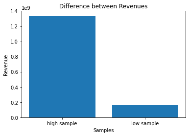

```python
plt.bar(["high sample", "low sample"], [df_highest_revs.revenue.mean(),df_low_revs.revenue.mean()])
plt.title("Difference between Revenues")
plt.xlabel("Samples")
plt.ylabel("Revenue");
```

```python
df_highest_revs.popularity.mean(),df_low_revs.popularity.mean()
```

```
(7.108372045454544, 1.482942017348202)
```

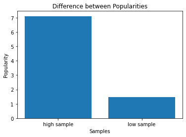

```python
plt.bar(["high sample", "low sample"], [df_highest_revs.popularity.mean(),df_low_revs.popularity.mean()])
plt.title("Difference between Popularities")
plt.xlabel("Samples")
plt.ylabel("Popularity");
```

```python
df_highest_revs.runtime.mean(),df_low_revs.runtime.mean()
```

```
(140.27272727272728, 111.80710450227178)
```

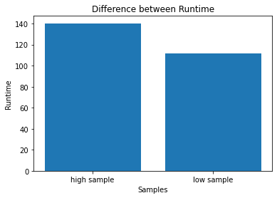

```python
plt.bar(["high sample", "low sample"], [df_highest_revs.runtime.mean(),df_low_revs.runtime.mean()])
plt.title("Difference between Runtime")
plt.xlabel("Samples")
plt.ylabel("Runtime");
```

```python
df_highest_revs.vote_count.mean(),df_low_revs.vote_count.mean()
```

```
(4779.727272727273, 714.8612143742255)
```

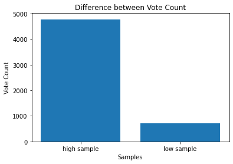

```python
plt.bar(["high sample", "low sample"], [df_highest_revs.vote_count.mean(),df_low_revs.vote_count.mean()])
plt.title("Difference between Vote Count")
plt.xlabel("Samples")
plt.ylabel("Vote Count");
```

```python
df_highest_revs.vote_average.mean(),df_low_revs.vote_average.mean()
```

```
(7.036363636363637, 6.263527467988434)
```

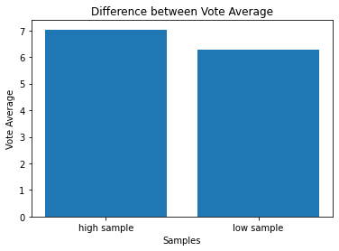

```python
plt.bar(["high sample", "low sample"], [df_highest_revs.vote_average.mean(),df_low_revs.vote_average.mean()])
plt.title("Difference between Vote Average")
plt.xlabel("Samples")
plt.ylabel("Vote Average");
```

```python
df_highest_revs.budget.mean(),df_low_revs.budget.mean()
```

```
(191000000.0, 47180222.375464685)
```

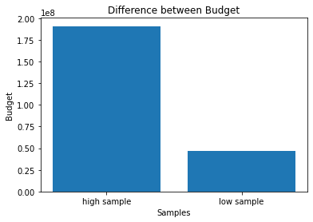

```python
plt.bar(["high sample", "low sample"], [df_highest_revs.budget.mean(),df_low_revs.budget.mean()])
plt.title("Difference between Budget")
plt.xlabel("Samples")
plt.ylabel("Budget");
```

```python
df_highest_revs.release_year.mean(),df_low_revs.release_year.mean()
```

```
(2010.0, 2001.4432052870714)
```

===> from that bar chars we could notice that the movies with high revenues have high popularity, runtime, vote count , vout average and budget

```python
df_low_sample= df_low_revs.groupby(['revenue','original_title']).median()
df_low_sample
```

| revenue | original_title | popularity | budget | runtime | vote_count | vote_average | release_year |
| --- | --- | --- | --- | --- | --- | --- | --- |
| 31063038 | High Anxiety | 0.560826 | 3400000 | 94 | 29 | 6.2 | 1977 |
| 31070211 | Ultraviolet | 1.133400 | 30000000 | 88 | 256 | 5.0 | 2006 |
| 31083599 | Premium Rush | 0.607856 | 35000000 | 91 | 592 | 6.1 | 2012 |
| 31148328 | Pride and Glory | 0.527398 | 30000000 | 130 | 118 | 6.3 | 2008 |
| 31155435 | How High | 0.499301 | 12000000 | 93 | 126 | 6.5 | 2001 |
| ... | ... | ... | ... | ... | ... | ... | ... |
| 955119788 | The Hobbit: The Battle of the Five Armies | 10.174599 | 250000000 | 144 | 3110 | 7.1 | 2014 |
| 958400000 | The Hobbit: The Desolation of Smaug | 4.310786 | 250000000 | 161 | 2952 | 7.6 | 2013 |
| 961000000 | Pirates of the Caribbean: At World's End | 4.965391 | 300000000 | 169 | 2626 | 6.8 | 2007 |
| 970761885 | Despicable Me 2 | 3.928789 | 76000000 | 98 | 3436 | 7.0 | 2013 |
| 976475550 | Harry Potter and the Philosopher's Stone | 8.021423 | 125000000 | 152 | 4265 | 7.2 | 2001 |

2421 rows × 6 columns

```python
df_new_sample= df_low_sample.tail(22)
df_new_sample
```

| revenue | original_title | popularity | budget | runtime | vote_count | vote_average | release_year |
| --- | --- | --- | --- | --- | --- | --- | --- |
| 850000000 | Star Wars: Episode III - Revenge of the Sith | 3.457537 | 113000000 | 140 | 2629 | 7.0 | 2005 |
| 853708609 | Inside Out | 6.326804 | 175000000 | 94 | 3935 | 8.0 | 2015 |
| 864625978 | Finding Nemo | 3.440519 | 94000000 | 100 | 3692 | 7.4 | 2003 |
| 871368364 | The Lord of the Rings: The Fellowship of the Ring | 8.575419 | 93000000 | 178 | 6079 | 7.8 | 2001 |
| 876688482 | Harry Potter and the Chamber of Secrets | 6.012584 | 100000000 | 161 | 3458 | 7.2 | 2002 |
| 877244782 | Ice Age: Continental Drift | 3.135776 | 95000000 | 88 | 1920 | 6.2 | 2012 |
| 880674609 | Spectre | 6.200282 | 245000000 | 148 | 3254 | 6.2 | 2015 |
| 886686817 | Ice Age: Dawn of the Dinosaurs | 3.154914 | 90000000 | 94 | 1392 | 6.4 | 2009 |
| 890871626 | Spider-Man 3 | 2.520912 | 258000000 | 139 | 2083 | 5.8 | 2007 |
| 895921036 | Harry Potter and the Goblet of Fire | 5.939927 | 150000000 | 157 | 3406 | 7.3 | 2005 |
| 919838758 | Shrek 2 | 2.191033 | 150000000 | 93 | 1676 | 6.5 | 2004 |
| 920100000 | Jurassic Park | 2.204926 | 63000000 | 127 | 3169 | 7.4 | 1993 |
| 924317558 | Star Wars: Episode I - The Phantom Menace | 3.526029 | 115000000 | 136 | 2823 | 6.3 | 1999 |
| 926287400 | The Lord of the Rings: The Two Towers | 8.095275 | 79000000 | 179 | 5114 | 7.8 | 2002 |
| 933959197 | Harry Potter and the Half-Blood Prince | 5.076472 | 250000000 | 153 | 3220 | 7.3 | 2009 |
| 938212738 | Harry Potter and the Order of the Phoenix | 4.878162 | 150000000 | 138 | 3382 | 7.2 | 2007 |
| 954305868 | Harry Potter and the Deathly Hallows: Part 1 | 4.840588 | 250000000 | 146 | 3467 | 7.4 | 2010 |
| 955119788 | The Hobbit: The Battle of the Five Armies | 10.174599 | 250000000 | 144 | 3110 | 7.1 | 2014 |
| 958400000 | The Hobbit: The Desolation of Smaug | 4.310786 | 250000000 | 161 | 2952 | 7.6 | 2013 |
| 961000000 | Pirates of the Caribbean: At World's End | 4.965391 | 300000000 | 169 | 2626 | 6.8 | 2007 |
| 970761885 | Despicable Me 2 | 3.928789 | 76000000 | 98 | 3436 | 7.0 | 2013 |
| 976475550 | Harry Potter and the Philosopher's Stone | 8.021423 | 125000000 | 152 | 4265 | 7.2 | 2001 |

```python
def mean ():
    column_name=['revenue','budget','popularity','vote_count','vote_average','release_year']
    for c in column_name:
        df_highest_revs[c].mean(),df_low_revs[c].mean()
        mean = df_highest_revs[c].mean(),df_low_revs[c].mean()

        print(c,mean)

mean()
```

```
revenue (1333941956.9545455, 156559603.92193308)
budget (191000000.0, 47180222.375464685)
popularity (7.108372045454544, 1.482942017348202)
vote_count (4779.727272727273, 714.8612143742255)
vote_average (7.036363636363637, 6.263527467988434)
release_year (2010.0, 2001.4432052870714)
```

## Conclusions

==> By comparing the mean for each column of my low & high samples we could figure out that although the low sample has more than 2000 movie but its means are < the high sample movies

===> because i did not deal with the data in revenue that has (0) value so i could delete them in another analysis or turn the (0) into (Nan) value then use fillna() to fill them from the budget value . In rows that have (0) in both columns i will delete them.